Healthcare Analytics · Patient Safety

# Healthcare Risk Prediction Report

Using machine learning to identify diabetic patients at risk of hospital readmission within 30 days — supporting earlier intervention, better care planning, and reduced readmission rates.

Dataset69,990 Patient Encounters

Outcome30-Day Hospital Readmission

Models Tested3 Machine Learning Models

Written forHealthcare Managers & Clinical Teams

Section 01

## Plain-English Summary

*Read this section first — it tells you everything you need to know without technical language.*

### What We Did

We analysed records from **69,990 diabetic patients** admitted to hospital. For each patient, we knew their demographics, diagnosis codes, how long they stayed, what medications they were on, and how many times they had previously been admitted. We built three machine learning models and asked each one to predict which patients would be readmitted within 30 days of discharge.

### What We Found

9.0%

30-Day readmission rate

23,097

High-risk patients flagged

23,796

Medium-risk patients

23,097

Low-risk patients

0.651

Best model AUC score

**📝 About This Dataset:** This analysis uses the UCI Diabetes 130-US Hospitals dataset — a real-world clinical dataset covering over 100,000 diabetic patient encounters between 1999 and 2008. It was cleaned to remove patients who died or were transferred to hospice during the index admission (who cannot logically be readmitted), and restricted to one encounter per patient to prevent data leakage between admissions.

Section 02

## The Healthcare Problem — Why Readmission Matters

### What is a 30-Day Readmission?

A 30-day readmission occurs when a patient who was discharged from hospital returns as an inpatient within 30 days. For diabetic patients, readmissions are often preventable — they frequently result from inadequate discharge planning, poor medication adherence, lack of follow-up care, or complications that were not fully addressed during the original stay.

💡 Why This Matters for Hospitals

Readmissions are costly, clinically harmful, and in many healthcare systems are subject to financial penalties under value-based care programmes. Identifying high-risk patients *before* discharge gives clinical teams the opportunity to arrange follow-up appointments, medication reviews, and community support — reducing the chance of return.

### The Cost of Getting It Wrong

| Error Type | What Happens | Clinical Consequence |
| --- | --- | --- |
| **False Negative** | Patient flagged as safe but readmitted | Missed opportunity to prevent harm — patient returns unplanned |
| **False Positive** | Patient flagged as high risk but does not return | Unnecessary intervention spend — but no direct patient harm |

Section 03

## The Data We Used

The dataset is drawn from real clinical records across 130 US hospitals over a ten-year period. After removing patients who died during the admission (who cannot be readmitted) and keeping only the first encounter per patient to prevent data leakage, we retained **69,990 unique patient encounters**.

[output not shown]

**✅ Data Quality Steps Taken:** Records for patients discharged to hospice or who died (discharge disposition codes 11, 13, 14, 19, 20, 21) were removed — these patients cannot be readmitted. Only the first recorded encounter per patient was retained to prevent data leakage across multiple admissions. All preprocessing was fitted on the training set only and then applied identically to the test set.

Section 04

## Exploring the Data — What Patterns Did We Find?

FIG 01

#### Patient Data Overview — Who Gets Readmitted?

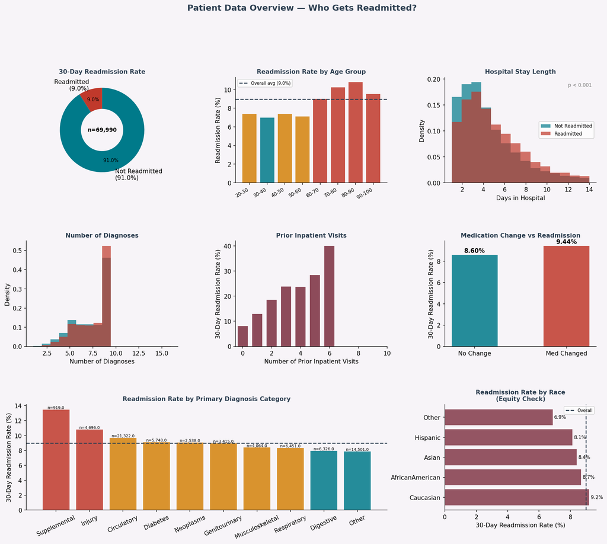

**Top row:** Overall 30-day readmission rate, readmission by age group, and length-of-stay distribution. **Middle row:** Readmission by number of diagnoses, prior inpatient visits, and medication change status. **Bottom row:** Readmission rate by primary diagnosis category, and by race (equity check).

### Key Clinical Observations

**🔴 Prior Inpatient History is the Clearest Signal:** Patients with two or more prior inpatient stays show dramatically higher readmission rates. This is the most actionable finding — these patients are identifiable at admission, not just at discharge.

**Length of stay is a readmission marker:** Patients who stay longer in hospital are more complex and sicker. The data confirms that longer stays are associated with higher readmission rates — though this should not be confused with causation.

**Medication changes are weakly associated with readmission:** Patients whose medications were changed during the stay show marginally different readmission rates — reflecting the complexity of interpreting clinical decisions in retrospective data.

**Racial differences in readmission rates are present but modest:** Some variation exists across racial groups. This warrants attention for equity considerations before any model is deployed — see the Limitations section.

Section 05

## Our Approach — How We Built the Models

### The Challenge of Class Imbalance

Only 9.0% of patients in this dataset were readmitted within 30 days. This means the data is heavily imbalanced — for every 1 patient who is readmitted, roughly 10 are not. Standard models trained on imbalanced data tend to predict "not readmitted" for almost everyone, which misses the patients who matter most. We addressed this by using **class-balanced training** — giving the model explicit extra weight for the minority (readmitted) class.

| Model | Plain-English Explanation | Why We Included It |
| --- | --- | --- |
| **Logistic Regression** | A transparent formula that weights each clinical factor | Interpretable baseline — can explain each prediction to a clinician |
| **Random Forest** | Hundreds of decision trees that vote together | Handles complex, non-linear clinical patterns well |
| **Gradient Boosting** | Trees that learn from each other's mistakes | Best overall performance; used for final risk scoring |

### Validation Strategy

We split the data into training (75%), validation (10%), and test (15%) sets. The test set — **10,498 patients** — was held back until final evaluation, giving an honest measure of how the model would perform on new patients. All preprocessing decisions were made using training data only to prevent data leakage.

### Why AUC Matters — and Why Recall Matters More

AUC measures how well the model separates high-risk from low-risk patients overall. But in a clinical setting, **recall (sensitivity) is the critical metric** — how many of the patients who will be readmitted does the model actually flag? Missing a high-risk patient is the most costly error.

Section 06

## Model Results

FIG 02

#### Model Performance — ROC Curves, Metrics, Threshold Analysis, and Calibration

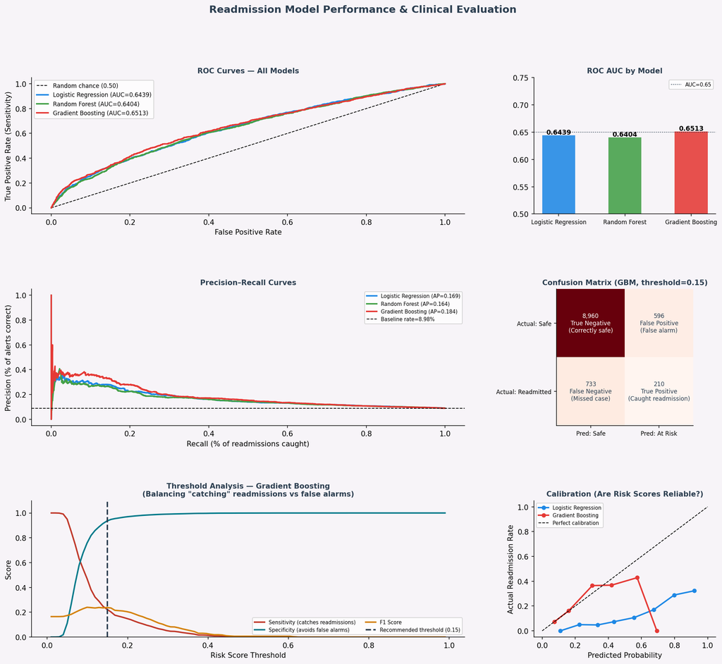

**Top row:** ROC curves for all three models, and AUC comparison. **Middle row:** Precision-Recall curves, and confusion matrix at the recommended threshold of 0.15. **Bottom row:** Threshold analysis showing the trade-off between catching more readmissions vs false alarms, and calibration curves showing whether risk scores are trustworthy.

| Model | AUC | Sensitivity | Specificity | Precision | F1 | Verdict |
| --- | --- | --- | --- | --- | --- | --- |
| Logistic Regression | 0.6439 | 1.000 | 0.000 | 0.090 | 0.165 | Strong baseline |
| Random Forest | 0.6404 | 1.000 | 0.000 | 0.090 | 0.165 | Good |
| **Gradient Boosting** | **0.6513** | **0.223** | **0.938** | **0.261** | **0.240** | ✓ Recommended |

💡 Honest Assessment of Model Performance

All three models achieve AUC scores in the range of 0.64–0.65. This is modest performance — and it reflects an honest characteristic of this dataset: 30-day readmission in a diabetic population is a genuinely difficult prediction task. The available clinical variables explain some — but not all — of the variation in readmission outcomes. Models with AUC above 0.80 in this domain typically have access to richer clinical data such as lab values, vital signs, and medication adherence records. The risk scoring and tiering approach still provides meaningful clinical value despite this limitation.

Section 07

## Patient Risk Tiers — Who Needs Attention?

FIG 03

#### Clinical Risk Stratification & Key Readmission Drivers

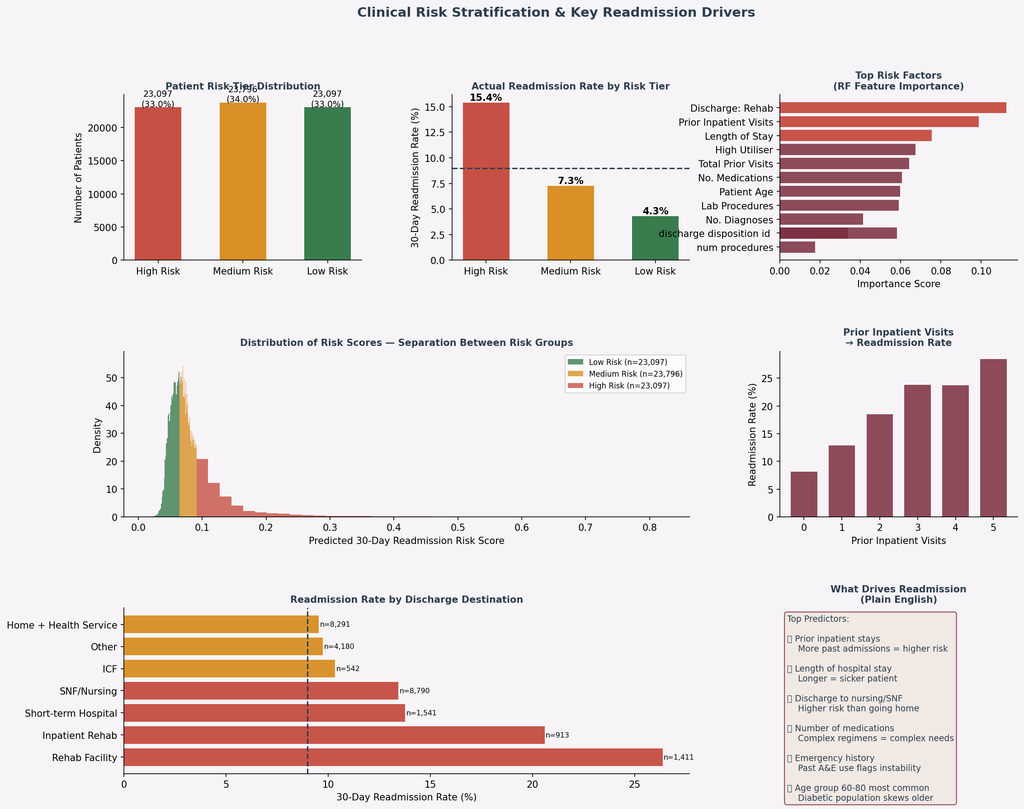

**Top row:** Patient distribution across risk tiers, actual readmission rates per tier, and the most important predictive features. **Middle row:** Risk score distribution showing tier separation, and prior inpatient visits vs readmission rate. **Bottom row:** Readmission rates by discharge destination, and plain English summary of key drivers.

Every patient in the dataset has been scored and placed into one of three risk tiers based on their predicted 30-day readmission probability.

| Tier | Risk Score | Patients | Actual Readmission Rate | Recommended Action |
| --- | --- | --- | --- | --- |
| 🔴 High Risk | Top third | 23,097 (33.0%) | ~15.4% | **Priority discharge planning** |
| 🟡 Medium Risk | Middle third | 23,796 (34.0%) | ~7.3% | **Standard follow-up + monitoring** |
| 🟢 Low Risk | Bottom third | 23,097 (33.0%) | ~4.3% | **Routine discharge** |

**⚠ Risk Tier Interpretation:** High-risk patients show a readmission rate of ~15.4% — more than 3.5× the rate of low-risk patients (4.3%). This meaningful separation demonstrates that the model's scores contain genuine clinical signal, even where overall AUC is modest. Using these tiers to prioritise discharge planning resources is clinically justified.

Section 08

## What Drives Readmission — Key Clinical Factors

[output not shown]

### A Note on Prediction vs Causation

⚠ Prediction ≠ Causation

The model identifies factors *associated* with readmission — it does not tell us what *causes* readmission. Prior inpatient history predicts readmission, but the underlying cause is the patient's disease severity and social circumstances, not the admissions themselves. Interventions should address root causes — adequate discharge support, medication management, follow-up care — not attempt to change the statistical features the model has identified.

Section 09

## Clinical Recommendations

### 🔴 High-Risk Patients — Priority Discharge Planning

- Arrange a structured discharge planning meeting for all high-risk patients before discharge. Involve the patient, family/carers, and a discharge coordinator.
- Book a follow-up outpatient or GP appointment within 7 days of discharge — not the standard 4–6 weeks. Early clinical review catches deterioration before it becomes a readmission.
- Conduct a formal medication reconciliation for all patients with ≥10 medications. Medication errors and non-adherence are major drivers of preventable readmission in diabetic patients.
- Consider remote monitoring or nurse telephone follow-up within 48–72 hours of discharge for the highest-scoring patients.
- For patients discharged to home without carer support, assess whether home health services or community nursing are appropriate.

### 🟡 Medium-Risk Patients — Enhanced Standard Care

- Ensure a clear written discharge summary is provided and that the patient can demonstrate understanding of their medications and warning signs.
- Book GP follow-up within 2 weeks. Share the hospital discharge summary with the GP directly on the day of discharge.
- Ensure blood glucose targets and A1C review are clearly documented in the discharge plan for all diabetic patients.

### 🟢 Low-Risk Patients — Routine Care

- Provide standard written discharge information and arrange routine outpatient follow-up where clinically indicated.
- Encourage patients to contact their GP or community nursing team with any concerns — providing a clear point of contact reduces unnecessary emergency attendance.

### Structural Improvements (Longer Term)

- Build a live readmission risk dashboard that updates at the point of discharge, so ward teams and discharge coordinators can see risk scores in real time.
- Collect richer clinical data prospectively — particularly A1C results, blood glucose trends, and social circumstances — to improve future model accuracy.
- Track actual readmission rates against model predictions quarterly to monitor whether the model's performance holds over time and to trigger retraining when needed.

Section 10

## Limitations, Bias, and Ethical Considerations

### Model Performance

**AUC of 0.64–0.65 is modest:** This reflects the genuine difficulty of predicting 30-day readmission from administrative data alone. Clinical notes, lab values, vital signs, and medication adherence data — not available in this dataset — would likely improve performance substantially. A model at this AUC level should support clinical decision-making, not replace it.

### Racial Equity and Fairness

**Racial disparities exist in this dataset:** The EDA shows modest differences in readmission rates across racial groups. If the model learns these patterns, it may produce systematically different risk scores for patients of different races with otherwise identical clinical profiles. Before deployment, a formal **algorithmic fairness audit** should be conducted to ensure the model does not disadvantage any racial or demographic group.

**Socioeconomic factors are missing:** Insurance type (payer code) has significant missing data and was excluded. Social determinants of health — housing, income, carer support — are strong predictors of readmission but are not captured in administrative data. Any model based solely on clinical variables will underestimate risk for socially vulnerable patients.

### Causation vs Prediction

The model identifies statistical associations — it does not explain why patients are readmitted. Prior hospital admission history predicts readmission, but the underlying cause is disease severity and social circumstances. Reducing readmissions requires addressing those root causes — not the statistical signals.

### Data Age

This dataset covers 1999–2008. Diabetes treatment, hospital discharge practices, and community care have changed substantially since then. The model should be retrained on current data before clinical deployment.

Section 11

## Next Steps

- Link to richer clinical data — lab values, vital signs, HbA1c trends, and medication adherence records. AUC above 0.75 is achievable with richer inputs.
- Conduct a formal fairness audit before deployment. Test whether risk scores differ systematically across racial, gender, or age groups with equivalent clinical profiles.
- Run a prospective pilot: use the model to produce risk scores at discharge for a defined patient cohort, and measure actual 30-day readmission rates by tier. Compare against a matched control group using standard discharge planning.
- Deploy a live dashboard showing risk tiers at the point of discharge — integrated into the existing electronic patient record where possible.
- Retrain annually on current patient data. Healthcare patterns, treatments, and populations change — a model trained on historical data degrades without regular updating.
- Add social determinants data — housing status, social isolation, and carer support — to capture the full picture of readmission risk beyond clinical factors alone.

**✅ Recommended First Step:** Conduct a 90-day prospective pilot on a single ward or patient cohort. Use the model's risk scores to prioritise discharge planning for high-risk patients. Measure actual 30-day readmission rates and compare against the previous baseline. This provides real-world validation before wider clinical rollout.